# Lecture 04: Command-Line Tools, Text Processing & Automation

From Bulk & scRNA-seq to Spatial Transcriptomics for Fighting Cancer – 2026

Hoang Tran

2026-09-30

## Important Resources for This Session

- Course Github repository: [Click here](https://github.com/luuloi/Fighting_Cancer_with_Transcriptomics).
- Companion Colab notebook: [Click here](https://colab.research.google.com/drive/1UNHppp8ae7l1IPzVrL5NSorNyxvtUZgx?usp=sharing).
- Linux Command Line Cheatsheet: [Click here](https://www.digitalocean.com/community/tutorials/linux-commands).
- Regular Expressions Cheatsheet: [Click here](https://cheatography.com/davechild/cheat-sheets/regular-expressions/).

## Where We Are in the Course

This lecture combines the original **Lecture 04** and **Lecture 06** into one longer session.

[figure not shown]

# 1. From Bash to Bioinformatics

## A Small Annotation Audit

A collaborator has sent us this project:

```
rnaseq_project/

├── annotation/
│   ├── gencode_subset.gtf
│   ├── gencode_subset.gtf.backup
│   └── notes.txt
│
├── metadata/
│   └── samples.tsv
│
└── results/
```

They ask:

> **Before we use the annotation, can you give me a quick QC report?**

## Questions for This Audit

1. Which annotation file do we have?
2. Which records are **protein-coding genes**?
3. Which of those genes are on the autosomes?
4. Which gene records are duplicated?
5. What are the chromosome, coordinates, and genomic span of each gene?
6. Can we save the results as a clean report?

**Note**

None of these questions requires opening the file in a GUI.

## What Would We Need?

- `find` – locate the annotation
- `grep` – select relevant lines
- regex – describe chromosome patterns
- `cut` - extract fields
- `sort` - organize values
- `uniq` - detect / count duplicates
- `sed` - transform text
- `awk` – apply logic and calculate
- connect the steps

**→ save the result**

## The Goal

- `find` – locate the annotation
- `grep` – select relevant lines
- regex – describe chromosome patterns
- `cut` - extract fields
- `sort` - organize values
- `uniq` - detect / count duplicates
- `sed` - transform text
- `awk` – apply logic and calculate
- connect the steps

By the end of this lecture, we should be able to turn a **messy annotation directory** into a **reproducible QC report** using ordinary command-line tools.

## Why Bioinformatics Data Works Well With CLI

The majority of genomic data is represented as **plain text**.

| File type | Typical structure |
| --- | --- |
| FASTA | sequences |
| FASTQ | sequences + quality |
| GTF / GFF | genomic annotations |
| BED | genomic intervals |
| TSV | tabular data |
| CSV | comma-separated data |

The presentation often follows:

**characters → lines → fields → patterns**

# 2. Anatomy of a Bioinformatics Text File

## Example: A GTF Record

```
chr17   HAVANA  gene        7661779  7687550  .  +  .  gene_id "TP53";
chr17   HAVANA  transcript  7661779  7687550  .  +  .  gene_id "TP53"; transcript_id "ENST...";
chr17   HAVANA  exon        7661779  7662590  .  +  .  gene_id "TP53"; transcript_id "ENST...";
```

One line is one **record**.

Each record contains multiple **fields**.

The fields are separated by a **delimiter**.

Here the main delimiter is a tab:

```
        ↓      ↓      ↓
chr17<TAB>HAVANA<TAB>gene<TAB>...
```

## Four Concepts to Remember

**Record:** One unit of information.

```
chr17   HAVANA   gene   ...
```

**Field:** One component of a record.

```
chr17
HAVANA
gene
7661779
```

**Pattern:** A piece of text we want to find.

```
TP53
gene
chr17
```

**Delimiter:** The character separating fields.

```
TAB
,
space
:
|
```

## Mini Exercise – Read the Record

Given:

```
chr17   HAVANA   gene   7661779   7687550   .   +   .   gene_id "TP53";
```

Answer:

1. How many tab-separated fields are visible?
2. Which field tells us the chromosome?
3. Which field tells us the feature type?
4. Where would you look for the gene ID?
5. What is the delimiter?

# 3. Five Core CLI Tools

## The Five Commands

Today we will build a mental model around five commands:

| Command | Question it answers |
| --- | --- |
| `find` | **Which file?** |
| `grep` | **Which lines?** |
| `cut` | **Which fields?** |
| `sort` | **In what order?** |
| `uniq` | **Which duplicates?** |

A useful workflow is:

```
find
  ↓
grep
  ↓
cut
  ↓
sort
  ↓
uniq
```

## Introducing a Lifesaver: `tldr`

Navigating the Linux filesystem was simple enough to memorize. But what happens when you start using more and more tools?

**That’s where our lifesaver comes in: `tldr`!**

`tldr` provides an ultra-condensed, example-focused alternative to `man` pages.

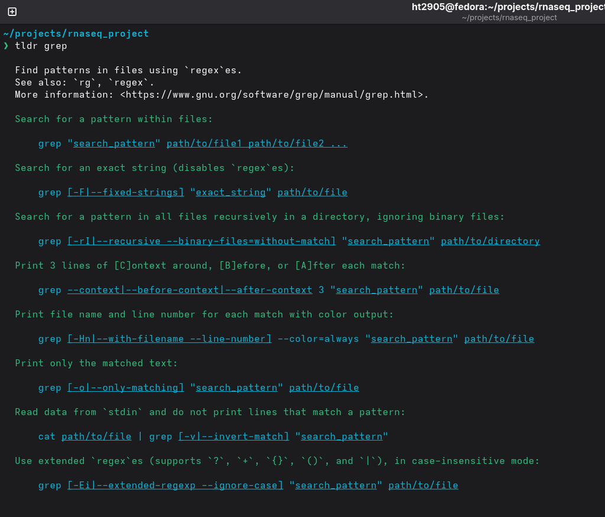

*Using `tldr` on `grep`*

## Installing `tldr` and `tealdeer`

For the classic `tldr` experience, install it with:

```bash
sudo apt install tldr
```

For a faster Rust implementation, try `tealdeer`:

```bash
sudo apt install tealdeer
```

Then update its cache:

```bash
tldr --update
```

> *Oh `tldr`, how can I ever live without you?*

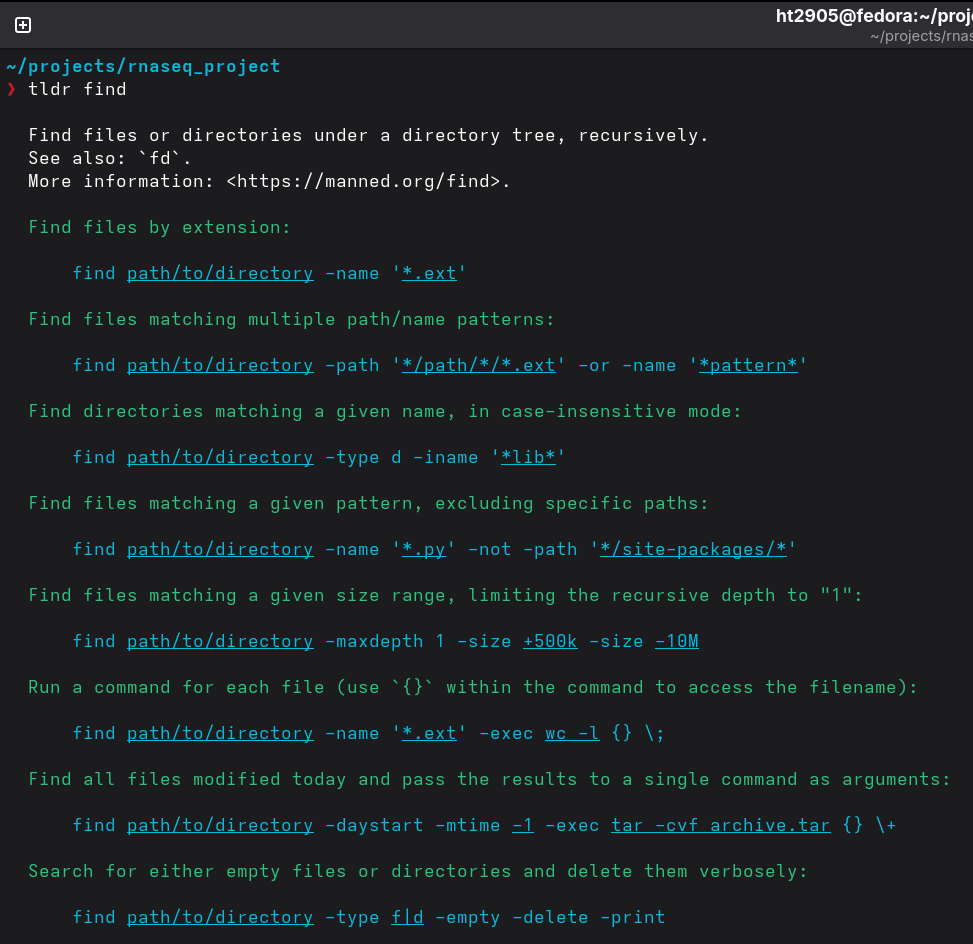

*Using `tldr` on `find`*

# Tool #1: `find`

## Searching the filesystem with `find`

Before searching inside a file, you need to know **which file exists where**.

`find` command anatomy:

```bash
find path/to/directory -name '*.ext'
```

Search the current directory:

```bash
find .
```

Find all GTF files:

```bash
find . -name "*.gtf"
```

Find regular files matching a pattern.

```bash
find . -type f -name "*.fastq.gz"
```

## Do Not Confuse `find` and `grep`!

Before searching inside a file, you need to know **which file exists where**.

`find` command anatomy:

```bash
find path/to/directory -name '*.ext'
```

> **`find` searches the filesystem, not the contents of files.**

This distinction is important because many people, including myself, frequently confuse `find` and `grep` when they first start out with Bash.

## `find` — Useful Options

Search recursively from `PATH`:

```bash
find PATH
```

Search only regular files:

```bash
find . -type f
```

Search only directories.

```bash
find . -type d
```

Search for name pattern:

```bash
find . -name "*.gtf"
```

Search using case-insensitive name matching:

```bash
find . -iname "*.GTF"
```

A realistic bioinformatics search:

```bash
find . -type f -name "*.fastq.gz"
```

# Tool #2: `grep`

## Searching File Contents With `grep`

`grep` answers:

> **Which lines contain this pattern?**

Example:

```bash
grep "TP53" genes.gtf
```

Only lines containing `TP53` are printed.

```bash
grep "gene" genes.gtf
```

Find lines containing the text `gene`.

```bash
grep -n "TP53" genes.gtf
```

Also show line numbers.

## `grep` as a Filter

[figure not shown]

Example:

```bash
grep "TP53" genes.gtf
```

Input:

```
chr17 ... BRCA1 ...
chr17 ... TP53 ...
chr17 ... EGFR ...
chr17 ... TP53 ...
```

Output:

```
chr17 ... TP53 ...
chr17 ... TP53 ...
```

## `grep` – Useful Options

Show line numbers:

```bash
grep -n "TP53" genes.gtf
```

Use case-insensitive matching:

```bash
grep -i "tp53" genes.gtf
```

Invert the match:

```bash
grep -v "exon" genes.gtf
```

Extended regular expressions (ERE):

```bash
grep -E "TP53|BRCA1" genes.gtf
```

Count matching lines:

```bash
grep -c "TP53" genes.gtf
```

# Regular Expressions (Regex)

## Regex: A Force Multiplier

The real power of CLI data processing tools comes from **regular expressions**, or **regex**.

A regex is a way of describing a **pattern of text**.

Compare:

`TP53`

with:

`^chr[0-9]+$`

The first means:

> Find exactly the characters TP53.

> What does the second string mean?

## Regex Vs. Regular Strings

Compare `TP53` with `^chr[0-9]+$`

The first means:

> Find exactly the characters TP53.

The second describes a much larger set of possible strings:

```
chr1
chr2
chr17
chr22
```

but not:

```
chrX
chromosome17
17
chr17_extra
```

# Basic Regex Building Blocks

## `.` – Match any character

Example:

`a.c` matches

```
abc
a1c
a-c
```

because `.` means:

> any single character

## `^` — Beginning of a line

`^chr`

means:

> chr must appear at the beginning of the line.

For example:

```
chr17
chrX
chrM
```

match.

But `my_chr17` does not.

This is useful for identifying structured lines such as FASTA headers or chromosome names.

## `$` — End of a line

`_old$`

means:

> _old must appear at the end of the line.

So:

```
gene_old
sample_old
```

match, but:

```
gene_old_version2
```

does not.

Together, `^` and `$` are called **anchors**.

They describe a **position** in the line rather than a character.

## `[]` – Character Classes

`[ABC]`

means:

> Match one character that is either `A`, `B`, or `C`.

For example:

`chr[XY]`

matches

```
chrX
chrY
```

## Using Ranges in Character Classes

`[ABC]`

means:

> Match one character that is either `A`, `B`, or `C`.

Ranges can also be used: `[0-9]` means

> any single digit from 0 to 9

`[A-Z]` means

> any uppercase letter

## Quantifiers — Matching Repeated Characters

Regex can also describe **how many times** something should appear.

| Operator | Meaning | Example | Matches |
| --- | --- | --- | --- |
| `*` | Zero or more | `ab*` | `a` `ab` `abb` `abbb` |
| `+` | One or more | `ab+` | `ab` `abb` `abbb` |
| `?` | Zero or one | `colou?r` | `color` `colour` |

## `|` — OR

The `|` operator means:

> Match **either** the pattern on the left or the pattern on the right.

For example:

`chrX|chrY`

matches:

```
chrX
chrY
```

but not:

```
chr17
chrM
```

It is useful when a pattern can have **multiple alternatives**.

## Combining Regex Components

Now we can build more useful patterns.

For example:

`^chr[0-9]+$`

means:

| Operator | Description |
| --- | --- |
| `^` | Beginning of line |
| `chr` | Literal text |
| `[0-9]` | One digit |
| `+` | One or more digits |
| `$` | End of line |

# Tool #3: `cut`

## Extracting Fields With `cut`

Suppose a TSV file contains:

```
gene_id gene_name   length
ENSG001 TP53    19149
ENSG002 BRCA1   134289
ENSG003 EGFR    121110
```

To extract the first field:

```bash
cut -f1 genes.tsv
```

Output:

```
gene_id
ENSG001
ENSG002
ENSG003
```

Extract field 2:

```bash
cut -f2 genes.tsv
```

## `cut` and Delimiters

For tab-separated data:

```bash
cut -f1 file.tsv
```

For comma-separated data:

```bash
cut -d',' -f2 file.csv
```

For colon-separated data:

```bash
cut -d':' -f1 file.txt
```

**General form:**

```bash
cut -d'DELIMITER' -fFIELD_NUMBER file
```

For tab-separated files, `-f` implies tab in common usage.

## `cut` Can Select Multiple Fields

```bash
cut -f1,3 genes.tsv
```

Fields 1 and 3.

```bash
cut -f1-3 genes.tsv
```

Fields 1 through 3.

```bash
cut -f2- genes.tsv
```

Field 2 through the end.

The key question is always:

> **What is the delimiter?**

# Tool #4: `sort`

## Ordering Text With `sort`

Order in alphabetical order:

```bash
sort genes.txt
```

Order in reverse order:

```bash
sort -r genes.txt
```

**Numerical sorting** requires a different mindset:

```bash
sort -n lengths.txt
```

Without `-n`, text is compared lexicographically (= as text).

## Numeric Sorting With `sort`

**Numerical sorting** requires a different mindset:

```bash
sort -n lengths.txt
```

Without `-n`, text is compared lexicographically (= as text).

Example:

```
10
2
30
4
```

Alphabetical sort can produce:

```
10
2
30
4
```

Numerical sort:

```
2
4
10
30
```

## Sorting by a Field

For TSV-like data:

```bash
sort -t$'\t' -k3,3 genes.tsv
```

Breakdown:

```
-t$'\t'   delimiter = TAB
-k3,3      sort using field 3
```

Numerical field sorting:

```bash
sort -t$'\t' -k3,3n genes.tsv
```

Reverse numerical sorting:

```bash
sort -t$'\t' -k3,3nr genes.tsv
```

# Tool #5: `uniq`

## Removing Adjacent Duplicates With `uniq`

Given:

```
BRCA1
BRCA1
EGFR
EGFR
TP53
TP53
TP53
```

```bash
uniq genes.txt
```

Output:

```
BRCA1
EGFR
TP53
```

But there is an important catch:

**`uniq` only removes adjacent duplicates.**

## What if Duplicates Aren’t Adjacent?

Input:

```
TP53
BRCA1
TP53
EGFR
BRCA1
```

Running:

```bash
uniq genes.txt
```

does **not** remove all duplicate values.

Instead:

```
TP53
BRCA1
TP53
EGFR
BRCA1
```

Nothing is adjacent.

## `uniq` Often Needs `sort`

Input:

```
TP53
BRCA1
TP53
EGFR
BRCA1
```

**Solution? Use `sort` first:**

```bash
sort genes.txt | uniq
```

first groups duplicates, then removes them.

**Note**

`|` is called the **pipe**. More in the next section.

## Counting Duplicates

`uniq -c` counts adjacent identical lines:

```bash
sort genes.txt | uniq -c
```

Example:

```
      2 BRCA1
      2 EGFR
      3 TP53
```

This is already useful bioinformatics information.

For example:

> Which gene IDs occur most often in this annotation subset?

# 4. Combine Commands Into Workflows

## The Pipe `|`

The pipe sends the output of one command to the input of another.

```bash
command_1 | command_2
```

Example:

```bash
grep "TP53" genes.gtf | cut -f1
```

First:

```
grep → keep matching records
```

Then:

```
cut → extract field 1
```

## Reading a Pipeline Left → Right

Consider:

```bash
grep "gene" genes.gtf | cut -f1 | sort | uniq
```

Read it as:

Keep gene records

↓

Extract chromosome

↓

Sort chromosomes

↓

Remove duplicates

## A More Useful Pipeline

Suppose field 3 is the feature type.

```bash
cut -f3 genes.gtf | sort | uniq -c
```

Possible output:

```
    120 exon
     25 gene
     40 transcript
```

Now the command is answering a biological/data question:

> **How many records of each feature type are present?**

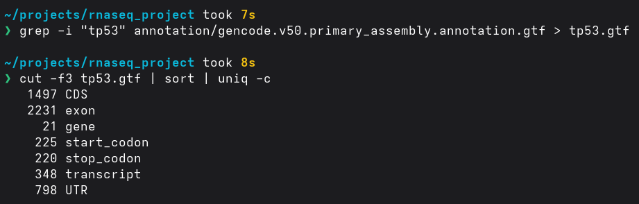

## Pipeline Debugging

When a long pipeline fails, split it.

Instead of:

```bash
grep "gene_id" genes.gtf | cut -f9 | sort | uniq -c
```

test:

```bash
grep "gene_id" genes.gtf
```

Then:

```bash
grep "gene_id" genes.gtf | cut -f9
```

Then:

```bash
grep "gene_id" genes.gtf | cut -f9 | sort
```

Then:

```bash
grep "gene_id" genes.gtf | cut -f9 | sort | uniq -c
```

Build complicated commands from verified small steps.

## Redirecting Output with `>`

`>` operator means **Write to a file**.

```bash
grep "TP53" genes.gtf > tp53_records.txt
```

Meaning:

**Run command**

↓

**Send stdout to file**

**Note**

If the file exists, `>` **overwrites** it.

## Appending to a File With `>>`

Suppose `selected_genes.txt` already contains:

```
TP53
```

Run:

```bash
grep "BRCA1" genes.gtf >> selected_genes.txt
```

Now the file contains:

```
TP53
BRCA1
```

`>>` **appends** (= adds to the end) instead of replacing the existing content.

**Note**

Unlike `>`, `>>` does **not overwrite** the existing file.

# 5. Advanced Data Processing Tools

# `sed` – Transforming Text

## Why `sed`?

`grep` is mainly for selecting lines.

`cut` is mainly for selecting fields.

Sometimes we need to **change text**.

- Replace one string
- Remove a suffix
- Transform a line

This is where `sed` comes in.

**Note**

`sed` = **s**tream **ed**itor

## Simple `sed` Example

Replace text:

```bash
sed 's/TP53/TUMOR_SUPPRESSOR/g' file.txt
```

General idea:

```bash
s/old/new/g
```

| Component | Description |
| --- | --- |
| `s` | Substitute |
| `old` | Text to find |
| `new` | Replacement text |
| `g` | Replace all matches on each line |

## `sed` Without `g`

| Component | Description |
| --- | --- |
| `s` | Substitute |
| `old` | Text to find |
| `new` | Replacement text |
| `g` | Replace all matches on each line |

Without `g`:

```bash
sed 's/TP53/TUMOR_SUPPRESSOR/' genes.txt
```

only the **first occurrence on each line** is replaced.

`sed` reads the input, applies a transformation, and prints the result.

By default, it does **not** modify the original file.

## `sed` Example: Remove a Chromosome Prefix

Suppose:

```
chr17
chr18
chrX
```

We want:

```
17
18
X
```

We can write:

```bash
sed 's/^chr//'
```

Here, `^chr` means:

> Find `chr` only when it appears at the beginning of the line.

So:

```
chr17
```

becomes:

```
17
```

The command does not remove every occurrence of `chr`.

It removes only a `chr` prefix.

## `sed` Example: Remove Unwanted Lines

GTF files often contain comment lines beginning with #:

```
##description: evidence-based annotation
# source: HAVANA
chr17 HAVANA gene ...
chr17 HAVANA transcript ...
```

To remove all comment lines:

```bash
sed '/^#/d' annotations.gtf
```

The important pieces are:

- `^#`: line starts with #
- `d`: delete the matching line

So the command means:

> Delete every line that begins with #.

## `sed` and Regex Capture Groups

Regex can also divide a match into **groups**.

For example:

```
chr17
chr18
chr22
```

Suppose we want to transform them into:

```
chromosome_17
chromosome_18
chromosome_22
```

With extended regular expressions (`sed -E`):

```bash
sed -E 's/^chr([0-9]+)$/chromosome_\1/'
```

The parentheses create a capture group: `([0-9]+)`

This means:

> Match one or more digits, and remember them.

## Inserting Captured Text

With extended regular expressions (`sed -E`):

```bash
sed -E 's/^chr([0-9]+)$/chromosome_\1/'
```

The parentheses create a capture group: `([0-9]+)`

After capture, the remembered text can then be inserted into the replacement: `\1`

So:

```
chr17
```

is interpreted as:

```
chr + 17
```

and becomes:

```
chromosome_17
```

This is one of the most useful regex techniques for reformatting structured biological data.

## More `sed` Examples

Remove a prefix:

```bash
sed 's/^chr//'
```

Convert:

```
chr17
chr18
chrX
```

into:

```
17
18
X
```

Remove a suffix:

```bash
sed 's/_old$//'
```